# MT_Project_LearnerNotebook_FullCode

## Problem Statement

### Business Context

Renewable energy sources play an increasingly important role in the global energy mix, as the effort to reduce the environmental impact of energy production increases.

Out of all the renewable energy alternatives, wind energy is one of the most developed technologies worldwide. The U.S Department of Energy has put together a guide to achieving operational efficiency using predictive maintenance practices.

Predictive maintenance uses sensor information and analysis methods to measure and predict degradation and future component capability. The idea behind predictive maintenance is that failure patterns are predictable and if component failure can be predicted accurately and the component is replaced before it fails, the costs of operation and maintenance will be much lower.

The sensors fitted across different machines involved in the process of energy generation collect data related to various environmental factors (temperature, humidity, wind speed, etc.) and additional features related to various parts of the wind turbine (gearbox, tower, blades, break, etc.).

## Objective

“ReneWind” is a company working on improving the machinery/processes involved in the production of wind energy using machine learning and has collected data of generator failure of wind turbines using sensors. They have shared a ciphered version of the data, as the data collected through sensors is confidential (the type of data collected varies with companies). Data has 40 predictors, 20000 observations in the training set and 5000 in the test set.

The objective is to build various classification models, tune them, and find the best one that will help identify failures so that the generators could be repaired before failing/breaking to reduce the overall maintenance cost. The nature of predictions made by the classification model will translate as follows:

- True positives (TP) are failures correctly predicted by the model. These will result in repairing costs.
- False negatives (FN) are real failures where there is no detection by the model. These will result in replacement costs.
- False positives (FP) are detections where there is no failure. These will result in inspection costs.

It is given that the cost of repairing a generator is much less than the cost of replacing it, and the cost of inspection is less than the cost of repair.

“1” in the target variables should be considered as “failure” and “0” represents “No failure”.

## Data Description

- The data provided is a transformed version of original data which was collected using sensors.
- Train.csv - To be used for training and tuning of models.
- Test.csv - To be used only for testing the performance of the final best model.
- Both the datasets consist of 40 predictor variables and 1 target variable

## Importing necessary libraries

```python
# To help with reading and manipulating data
import pandas as pd
import numpy as np

# To help with data visualization
%matplotlib inline
import matplotlib.pyplot as plt
import seaborn as sns

# To be used for missing value imputation
from sklearn.impute import SimpleImputer

# To help with model building
from sklearn.linear_model import LogisticRegression
from sklearn.tree import DecisionTreeClassifier
from sklearn.ensemble import (
    AdaBoostClassifier,
    GradientBoostingClassifier,
    RandomForestClassifier,
    BaggingClassifier,
)
from xgboost import XGBClassifier

# To get different metric scores, and split data
from sklearn import metrics
from sklearn.model_selection import train_test_split, StratifiedKFold, cross_val_score
from sklearn.metrics import (
    f1_score,
    accuracy_score,
    recall_score,
    precision_score,
    confusion_matrix,
    roc_auc_score,
    plot_confusion_matrix,
)
# To impute missing values
from sklearn.impute import KNNImputer

# To be used for data scaling and one hot encoding
from sklearn.preprocessing import StandardScaler, MinMaxScaler, OneHotEncoder

# To be used for tuning the model
from sklearn.model_selection import GridSearchCV, RandomizedSearchCV

# To oversample and undersample data
from imblearn.over_sampling import SMOTE
from imblearn.under_sampling import RandomUnderSampler

# To be used for creating pipelines and personalizing them
from sklearn.pipeline import Pipeline
from sklearn.compose import ColumnTransformer

# To define maximum number of columns to be displayed in a dataframe
pd.set_option("display.max_columns", None)

# To supress scientific notations for a dataframe
pd.set_option("display.float_format", lambda x: "%.3f" % x)

# To supress warnings
import warnings

warnings.filterwarnings("ignore")

# This will help in making the Python code more structured automatically (good coding practice)
#%load_ext nb_black
```

## Loading the dataset

```python
# Load the Drive helper and mount
from google.colab import drive

# This will prompt for authorization.
drive.mount('/content/drive', force_remount=True)
```

```python
# After executing the cell above, Drive
# files will be present in "/content/drive/My Drive".
%cd "/content/drive/My Drive"
```

```
/content/drive/My Drive
```

## Data Overview

```python
#importing Train DataFrame with the name "Train.csv"
data=pd.read_csv('Train.csv')
data.head()
```

|  | V1 | V2 | V3 | V4 | V5 | V6 | V7 | V8 | V9 | V10 | V11 | V12 | V13 | V14 | V15 | V16 | V17 | V18 | V19 | V20 | V21 | V22 | V23 | V24 | V25 | V26 | V27 | V28 | V29 | … |
| --- | --- | --- | --- | --- | --- | --- | --- | --- | --- | --- | --- | --- | --- | --- | --- | --- | --- | --- | --- | --- | --- | --- | --- | --- | --- | --- | --- | --- | --- | --- |
| 0 | -4.465 | -4.679 | 3.102 | 0.506 | -0.221 | -2.033 | -2.911 | 0.051 | -1.522 | 3.762 | -5.715 | 0.736 | 0.981 | 1.418 | -3.376 | -3.047 | 0.306 | 2.914 | 2.270 | 4.395 | -2.388 | 0.646 | -1.191 | 3.133 | 0.665 | -2.511 | -0.037 | 0.726 | -3.982 | … |
| 1 | 3.366 | 3.653 | 0.910 | -1.368 | 0.332 | 2.359 | 0.733 | -4.332 | 0.566 | -0.101 | 1.914 | -0.951 | -1.255 | -2.707 | 0.193 | -4.769 | -2.205 | 0.908 | 0.757 | -5.834 | -3.065 | 1.597 | -1.757 | 1.766 | -0.267 | 3.625 | 1.500 | -0.586 | 0.783 | … |
| 2 | -3.832 | -5.824 | 0.634 | -2.419 | -1.774 | 1.017 | -2.099 | -3.173 | -2.082 | 5.393 | -0.771 | 1.107 | 1.144 | 0.943 | -3.164 | -4.248 | -4.039 | 3.689 | 3.311 | 1.059 | -2.143 | 1.650 | -1.661 | 1.680 | -0.451 | -4.551 | 3.739 | 1.134 | -2.034 | … |
| 3 | 1.618 | 1.888 | 7.046 | -1.147 | 0.083 | -1.530 | 0.207 | -2.494 | 0.345 | 2.119 | -3.053 | 0.460 | 2.705 | -0.636 | -0.454 | -3.174 | -3.404 | -1.282 | 1.582 | -1.952 | -3.517 | -1.206 | -5.628 | -1.818 | 2.124 | 5.295 | 4.748 | -2.309 | -3.963 | … |
| 4 | -0.111 | 3.872 | -3.758 | -2.983 | 3.793 | 0.545 | 0.205 | 4.849 | -1.855 | -6.220 | 1.998 | 4.724 | 0.709 | -1.989 | -2.633 | 4.184 | 2.245 | 3.734 | -6.313 | -5.380 | -0.887 | 2.062 | 9.446 | 4.490 | -3.945 | 4.582 | -8.780 | -3.383 | 5.107 | … |

```python
data.shape
```

```
(20000, 41)
```

```python
data.info()
```

```
<class 'pandas.core.frame.DataFrame'>
RangeIndex: 20000 entries, 0 to 19999
Data columns (total 41 columns):
 #   Column  Non-Null Count  Dtype
---  ------  --------------  -----
 0   V1      19982 non-null  float64
 1   V2      19982 non-null  float64
 2   V3      20000 non-null  float64
 3   V4      20000 non-null  float64
 4   V5      20000 non-null  float64
 5   V6      20000 non-null  float64
 6   V7      20000 non-null  float64
 7   V8      20000 non-null  float64
 8   V9      20000 non-null  float64
 9   V10     20000 non-null  float64
```

[output cut: 33 more lines]

```python
data.isnull().sum()
```

```
V1        18
V2        18
V3         0
V4         0
V5         0
V6         0
V7         0
V8         0
V9         0
V10        0
V11        0
V12        0
V13        0
V14        0
V15        0
V16        0
V17        0
V18        0
V19        0
V20        0
V21        0
V22        0
V23        0
V24        0
V25        0
V26        0
V27        0
V28        0
V29        0
V30        0
V31        0
V32        0
V33        0
V34        0
V35        0
V36        0
V37        0
V38        0
V39        0
V40        0
Target     0
dtype: int64
```

```python
# There are missing values for sensor V1 and V2. 18 each.
```

## Exploratory Data Analysis (EDA)

```python
data.describe().T
```

|  | count | mean | std | min | 25% | 50% | 75% | max |
| --- | --- | --- | --- | --- | --- | --- | --- | --- |
| V1 | 19982.000 | -0.272 | 3.442 | -11.876 | -2.737 | -0.748 | 1.840 | 15.493 |
| V2 | 19982.000 | 0.440 | 3.151 | -12.320 | -1.641 | 0.472 | 2.544 | 13.089 |
| V3 | 20000.000 | 2.485 | 3.389 | -10.708 | 0.207 | 2.256 | 4.566 | 17.091 |
| V4 | 20000.000 | -0.083 | 3.432 | -15.082 | -2.348 | -0.135 | 2.131 | 13.236 |
| V5 | 20000.000 | -0.054 | 2.105 | -8.603 | -1.536 | -0.102 | 1.340 | 8.134 |
| V6 | 20000.000 | -0.995 | 2.041 | -10.227 | -2.347 | -1.001 | 0.380 | 6.976 |
| V7 | 20000.000 | -0.879 | 1.762 | -7.950 | -2.031 | -0.917 | 0.224 | 8.006 |
| V8 | 20000.000 | -0.548 | 3.296 | -15.658 | -2.643 | -0.389 | 1.723 | 11.679 |
| V9 | 20000.000 | -0.017 | 2.161 | -8.596 | -1.495 | -0.068 | 1.409 | 8.138 |
| V10 | 20000.000 | -0.013 | 2.193 | -9.854 | -1.411 | 0.101 | 1.477 | 8.108 |
| V11 | 20000.000 | -1.895 | 3.124 | -14.832 | -3.922 | -1.921 | 0.119 | 11.826 |
| V12 | 20000.000 | 1.605 | 2.930 | -12.948 | -0.397 | 1.508 | 3.571 | 15.081 |
| V13 | 20000.000 | 1.580 | 2.875 | -13.228 | -0.224 | 1.637 | 3.460 | 15.420 |
| V14 | 20000.000 | -0.951 | 1.790 | -7.739 | -2.171 | -0.957 | 0.271 | 5.671 |
| V15 | 20000.000 | -2.415 | 3.355 | -16.417 | -4.415 | -2.383 | -0.359 | 12.246 |
| V16 | 20000.000 | -2.925 | 4.222 | -20.374 | -5.634 | -2.683 | -0.095 | 13.583 |
| V17 | 20000.000 | -0.134 | 3.345 | -14.091 | -2.216 | -0.015 | 2.069 | 16.756 |
| V18 | 20000.000 | 1.189 | 2.592 | -11.644 | -0.404 | 0.883 | 2.572 | 13.180 |
| V19 | 20000.000 | 1.182 | 3.397 | -13.492 | -1.050 | 1.279 | 3.493 | 13.238 |
| V20 | 20000.000 | 0.024 | 3.669 | -13.923 | -2.433 | 0.033 | 2.512 | 16.052 |
| V21 | 20000.000 | -3.611 | 3.568 | -17.956 | -5.930 | -3.533 | -1.266 | 13.840 |
| V22 | 20000.000 | 0.952 | 1.652 | -10.122 | -0.118 | 0.975 | 2.026 | 7.410 |
| V23 | 20000.000 | -0.366 | 4.032 | -14.866 | -3.099 | -0.262 | 2.452 | 14.459 |
| V24 | 20000.000 | 1.134 | 3.912 | -16.387 | -1.468 | 0.969 | 3.546 | 17.163 |
| V25 | 20000.000 | -0.002 | 2.017 | -8.228 | -1.365 | 0.025 | 1.397 | 8.223 |
| V26 | 20000.000 | 1.874 | 3.435 | -11.834 | -0.338 | 1.951 | 4.130 | 16.836 |
| V27 | 20000.000 | -0.612 | 4.369 | -14.905 | -3.652 | -0.885 | 2.189 | 17.560 |
| V28 | 20000.000 | -0.883 | 1.918 | -9.269 | -2.171 | -0.891 | 0.376 | 6.528 |
| V29 | 20000.000 | -0.986 | 2.684 | -12.579 | -2.787 | -1.176 | 0.630 | 10.722 |
| V30 | 20000.000 | -0.016 | 3.005 | -14.796 | -1.867 | 0.184 | 2.036 | 12.506 |
| V31 | 20000.000 | 0.487 | 3.461 | -13.723 | -1.818 | 0.490 | 2.731 | 17.255 |
| V32 | 20000.000 | 0.304 | 5.500 | -19.877 | -3.420 | 0.052 | 3.762 | 23.633 |
| V33 | 20000.000 | 0.050 | 3.575 | -16.898 | -2.243 | -0.066 | 2.255 | 16.692 |
| V34 | 20000.000 | -0.463 | 3.184 | -17.985 | -2.137 | -0.255 | 1.437 | 14.358 |
| V35 | 20000.000 | 2.230 | 2.937 | -15.350 | 0.336 | 2.099 | 4.064 | 15.291 |
| V36 | 20000.000 | 1.515 | 3.801 | -14.833 | -0.944 | 1.567 | 3.984 | 19.330 |
| V37 | 20000.000 | 0.011 | 1.788 | -5.478 | -1.256 | -0.128 | 1.176 | 7.467 |
| V38 | 20000.000 | -0.344 | 3.948 | -17.375 | -2.988 | -0.317 | 2.279 | 15.290 |
| V39 | 20000.000 | 0.891 | 1.753 | -6.439 | -0.272 | 0.919 | 2.058 | 7.760 |
| V40 | 20000.000 | -0.876 | 3.012 | -11.024 | -2.940 | -0.921 | 1.120 | 10.654 |
| Target | 20000.000 | 0.056 | 0.229 | 0.000 | 0.000 | 0.000 | 0.000 | 1.000 |

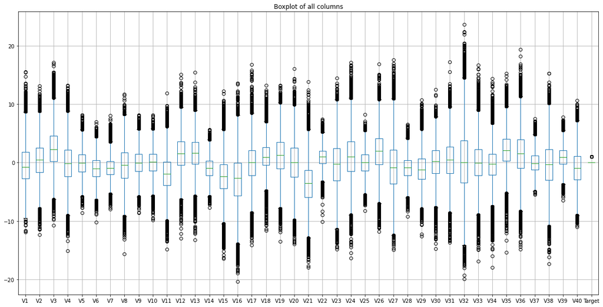

```python
plt.figure(figsize=(20,10))

data.boxplot();
plt.title('Boxplot of all columns');
```

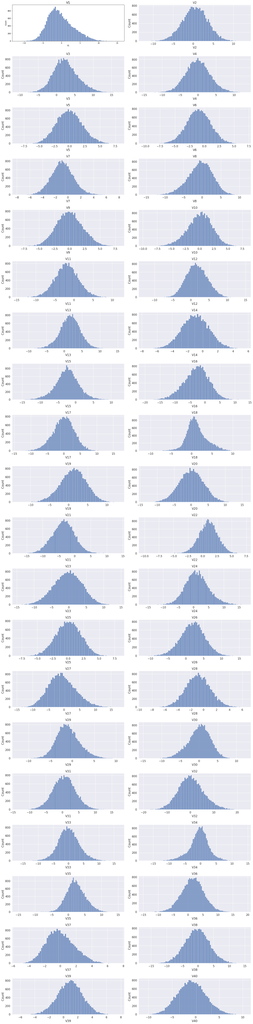

```python
plt.figure(figsize=(20, 80))

# numerical columns
columns=data.drop(['Target'], axis=1).dtypes[data.drop(['Target'], axis=1).dtypes != 'object'].index

# plot
for i, variable in enumerate(columns):
    plt.subplot(20, 2, i + 1)
    sns.set(font_scale = 1.4)
    sns.histplot(data= data, x=variable)
    plt.tight_layout()
    plt.title(variable)
```

```python
# Generally speaking, most of the data is normally distributed. Few features are skewed
```

### Plotting histograms and boxplots for all the variables

```python
# function to plot a boxplot and a histogram along the same scale.


def histogram_boxplot(data, feature, figsize=(12, 7), kde=False, bins=None):
    """
    Boxplot and histogram combined

    data: dataframe
    feature: dataframe column
    figsize: size of figure (default (12,7))
    kde: whether to the show density curve (default False)
    bins: number of bins for histogram (default None)
    """
    f2, (ax_box2, ax_hist2) = plt.subplots(
        nrows=2,  # Number of rows of the subplot grid= 2
        sharex=True,  # x-axis will be shared among all subplots
        gridspec_kw={"height_ratios": (0.25, 0.75)},
        figsize=figsize,
    )  # creating the 2 subplots
    sns.boxplot(
        data=data, x=feature, ax=ax_box2, showmeans=True, color="violet"
    )  # boxplot will be created and a star will indicate the mean value of the column
    sns.histplot(
        data=data, x=feature, kde=kde, ax=ax_hist2, bins=bins, palette="winter"
    ) if bins else sns.histplot(
        data=data, x=feature, kde=kde, ax=ax_hist2
    )  # For histogram
    ax_hist2.axvline(
        data[feature].mean(), color="green", linestyle="--"
    )  # Add mean to the histogram
    ax_hist2.axvline(
        data[feature].median(), color="black", linestyle="-"
    )  # Add median to the histogram
```

### Plotting all the features at one go

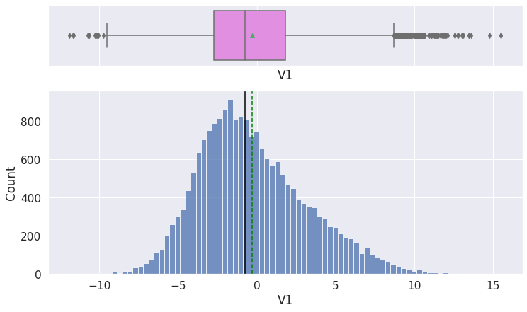

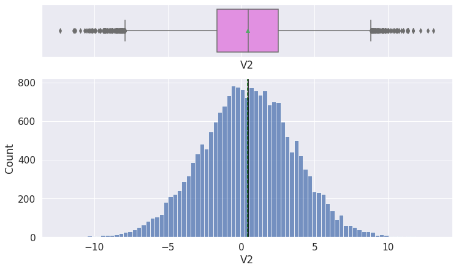

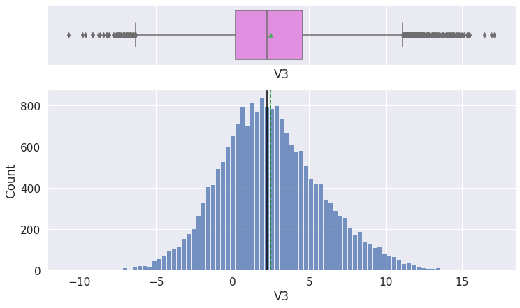

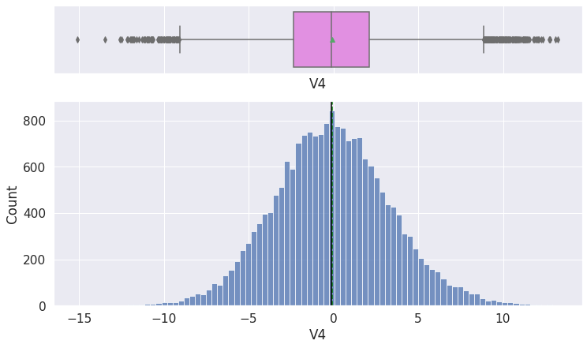

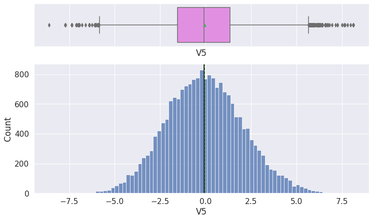

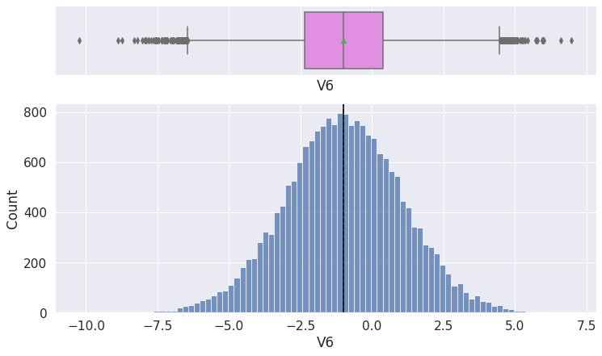

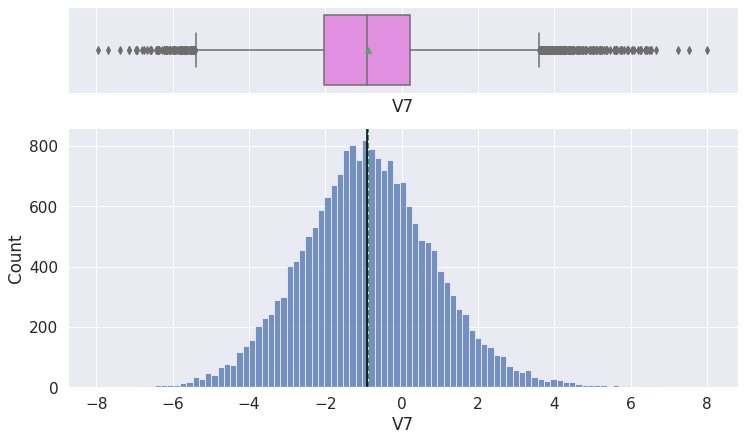

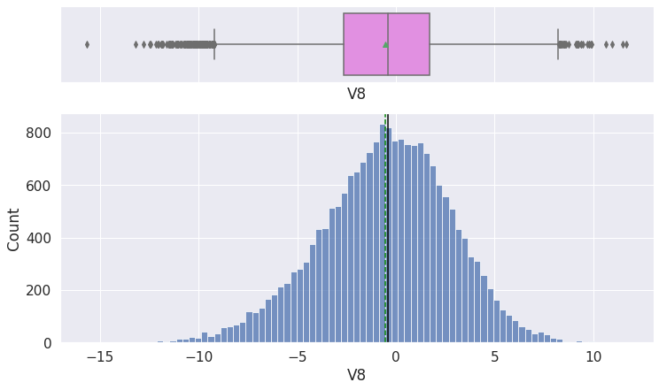

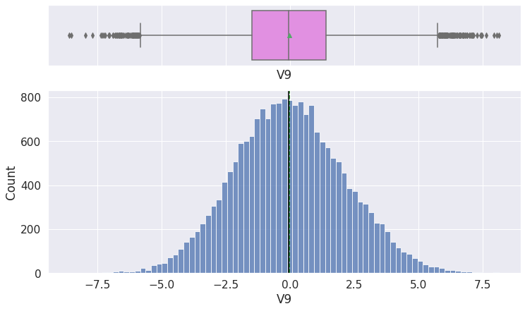

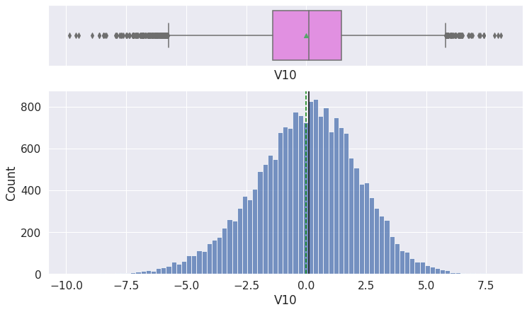

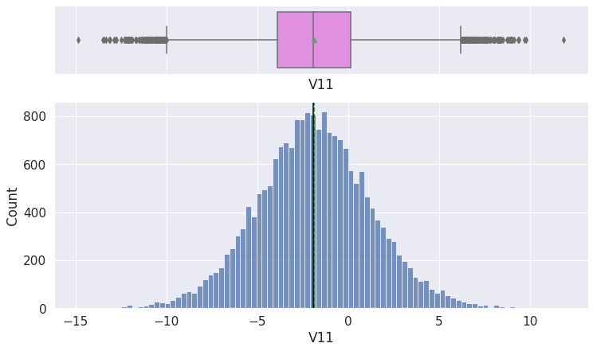

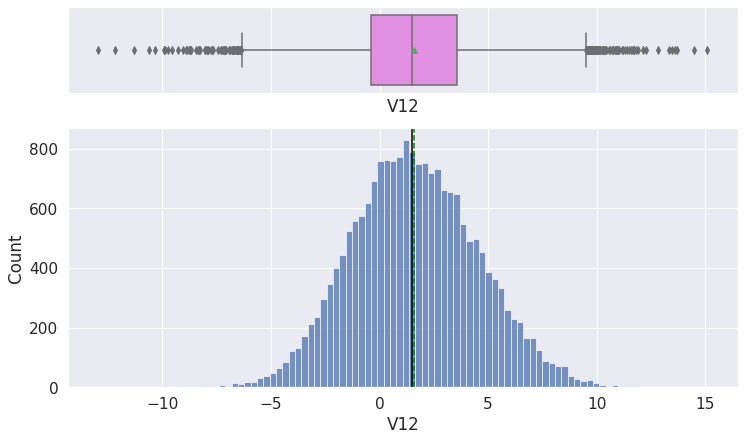

[29 more figures not shown]

```python
for feature in data.columns:
    histogram_boxplot(data, feature, figsize=(12, 7), kde=False, bins=None) ## Please change the dataframe name as you define while reading the data
```

## Data Pre-processing

```python
# Make a copy of the data
data1 = data.copy()

# Count the number of duplicates in rows
data1.duplicated().sum()
print('Among the {} rows of the dataframe {} rows are unique and {} rows are duplicates.'.format(data.shape[0] , (~data.duplicated()).sum(), data.duplicated().sum()))
```

```
Among the 20000 rows of the dataframe 20000 rows are unique and 0 rows are duplicates.
```

```python
##### Defining predictors(x) and target (y) variables in data1
X=data1.drop(['Target'], axis=1)
y=data1[['Target']]

# We already have a test set which we will later upload
# We only need to split data1 into train and validation sets in 75:25 ratio

X_train, X_val, y_train, y_val = train_test_split(
    X, y, test_size=0.25, random_state=1, stratify=y
)
```

```python
#importing Test DataFrame with the name "Test.csv"
data_test=pd.read_csv('Test.csv')

# Seperating X and Y variables
X_test=data_test.drop(['Target'], axis=1)
y_test=data_test[['Target']]
```

```python
print("Number of rows in train data =", X_train.shape[0]);
print("Number of rows in validation data =", X_val.shape[0]);
print("Number of rows in test data =", X_test.shape[0]);
```

```
Number of rows in train data = 15000
Number of rows in validation data = 5000
Number of rows in test data = 5000
```

```python
target='Target'

print("\nNumber (percentage) of {} is as follow:".format(target))

print("\nWhole DataFrame:")
print("failure:      {0} ({1:2.2f}%)".format(data1[target].value_counts()[1], data1[target].value_counts(normalize=True)[1] * 100 ))
print("no failure:   {0} ({1:2.2f}%)".format(data1[target].value_counts()[0], data1[target].value_counts(normalize=True)[0] * 100 ))


print("\nTraining Set:")
print("failure:      {0} ({1:2.2f}%)".format(y_train[target].value_counts()[1], y_train[target].value_counts(normalize=True)[1] * 100 ))
print("no failure:   {0} ({1:2.2f}%)".format(y_train[target].value_counts()[0], y_train[target].value_counts(normalize=True)[0] * 100 ))

print("\nValidation Set:")
print("failure:      {0} ({1:2.2f}%)".format(y_val[target].value_counts()[1], y_val[target].value_counts(normalize=True)[1] * 100 ))
print("no failure:   {0} ({1:2.2f}%)".format(y_val[target].value_counts()[0], y_val[target].value_counts(normalize=True)[0] * 100 ))


print("\nTest Set:")
print("failure:      {0} ({1:2.2f}%)".format(y_test[target].value_counts()[1], y_test[target].value_counts(normalize=True)[1] * 100 ))
print("no failure:   {0} ({1:2.2f}%)".format(y_test[target].value_counts()[0], y_test[target].value_counts(normalize=True)[0] * 100 ))
```

```
Number (percentage) of Target is as follow:

Whole DataFrame:
failure:      1110 (5.55%)
no failure:   18890 (94.45%)

Training Set:
failure:      832 (5.55%)
no failure:   14168 (94.45%)

Validation Set:
failure:      278 (5.56%)
no failure:   4722 (94.44%)

Test Set:
failure:      282 (5.64%)
no failure:   4718 (94.36%)
```

## Missing value imputation

```python
col_for_imputation = X_train.isnull().sum()[X_train.isnull().sum()>0].index.tolist()
```

```python
imputer = KNNImputer(n_neighbors=5);
impute = imputer.fit(X_train[col_for_imputation])
```

```python
# Next, we use the built imputer to transform all three train, validation, and test sets
X_train[col_for_imputation] = impute.transform(X_train[col_for_imputation])
X_val[col_for_imputation] = imputer.transform(X_val[col_for_imputation])
X_test[col_for_imputation] = imputer.transform(X_test[col_for_imputation])
```

```python
print('Number of missing valuse in train set = {}.'.format(X_train.isnull().sum().sum()))
print('Number of missing valuse in validation set = {}.'.format(X_val.isnull().sum().sum()))
print('Number of missing valuse in test set = {}.'.format(X_test.isnull().sum().sum()))
```

```
Number of missing valuse in train set = 0.
Number of missing valuse in validation set = 0.
Number of missing valuse in test set = 0.
```

## Model Building

### Model evaluation criterion

The nature of predictions made by the classification model will translate as follows:

- True positives (TP) are failures correctly predicted by the model.
- False negatives (FN) are real failures in a generator where there is no detection by model.
- False positives (FP) are failure detections in a generator where there is no failure.

**Which metric to optimize?**

- We need to choose the metric which will ensure that the maximum number of generator failures are predicted correctly by the model.
- We would want Recall to be maximized as greater the Recall, the higher the chances of minimizing false negatives.
- We want to minimize false negatives because if a model predicts that a machine will have no failure when there will be a failure, it will increase the maintenance cost.

**Let's define a function to output different metrics (including recall) on the train and test set and a function to show confusion matrix so that we do not have to use the same code repetitively while evaluating models.**

```python
# defining a function to compute different metrics to check performance of a classification model built using sklearn
def model_performance_classification_sklearn(model, predictors, target):
    """
    Function to compute different metrics to check classification model performance

    model: classifier
    predictors: independent variables
    target: dependent variable
    """

    # predicting using the independent variables
    pred = model.predict(predictors)

    acc = accuracy_score(target, pred)  # to compute Accuracy
    recall = recall_score(target, pred)  # to compute Recall
    precision = precision_score(target, pred)  # to compute Precision
    f1 = f1_score(target, pred)  # to compute F1-score

    # creating a dataframe of metrics
    df_perf = pd.DataFrame(
        {
            "Accuracy": acc,
            "Recall": recall,
            "Precision": precision,
            "F1": f1

        },
        index=[0],
    )

    return df_perf
```

```python
def confusion_matrix_sklearn(model, predictors, target):
    """
    To plot the confusion_matrix with percentages

    model: classifier
    predictors: independent variables
    target: dependent variable
    """
    y_pred = model.predict(predictors)
    cm = confusion_matrix(target, y_pred)
    labels = np.asarray(
        [
            ["{0:0.0f}".format(item) + "\n{0:.2%}".format(item / cm.flatten().sum())]
            for item in cm.flatten()
        ]
    ).reshape(2, 2)


    sns.set(font_scale = 1.1)
    plt.figure(figsize=(6, 4))
    sns.heatmap(cm, annot=labels, fmt="", cmap="Greens_r")
    plt.ylabel("True label")
    plt.xlabel("Predicted label")
```

### Defining scorer to be used for cross-validation and hyperparameter tuning

- We want to reduce false negatives and will try to maximize "Recall".
- To maximize Recall, we can use Recall as a **scorer** in cross-validation and hyperparameter tuning.

```python
# Type of scoring used to compare parameter combinations
scorer = metrics.make_scorer(metrics.recall_score)
```

### Model Building with original data

Sample Decision Tree model building with original data

```python
models = []  # Empty list to store all the models

# Appending models into the list
models.append(("LR", LogisticRegression(random_state=1)))
models.append(("dtree", DecisionTreeClassifier(random_state=1)))
models.append(("Bagging", BaggingClassifier(random_state=1)))
models.append(("Random Forest", RandomForestClassifier(random_state=1)))
models.append(("GBM", GradientBoostingClassifier(random_state=1)))
models.append(("Adaboost", AdaBoostClassifier(random_state=1)))
models.append(("Xgboost", XGBClassifier(random_state=1, eval_metric="logloss")))

results = []  # Empty list to store all model's CV scores
names = []  # Empty list to store name of the models
```

```python
models = []  # Empty list to store all the models

# Appending models into the list
models.append(("LR", LogisticRegression(random_state=1)))
models.append(("dtree", DecisionTreeClassifier(random_state=1)))
models.append(("Bagging", BaggingClassifier(random_state=1)))
models.append(("Random Forest", RandomForestClassifier(random_state=1)))
models.append(("GBM", GradientBoostingClassifier(random_state=1)))
models.append(("Adaboost", AdaBoostClassifier(random_state=1)))
models.append(("Xgboost", XGBClassifier(random_state=1, eval_metric="logloss")))

results = []  # Empty list to store all model's CV scores
names = []  # Empty list to store name of the models


# loop through all models to get the mean cross validated score
print("\n" "Cross-Validation performance on training dataset:" "\n")

for name, model in models:
    kfold = StratifiedKFold(
        n_splits=5, shuffle=True, random_state=1
    )  # Setting number of splits equal to 5
    cv_result = cross_val_score(
        estimator=model, X=X_train, y=y_train, scoring=scorer, cv=kfold
    )
    results1.append(cv_result)
    names.append(name)
    print("{}: {}".format(name, cv_result.mean()))

print("\n" "Validation Performance:" "\n")

for name, model in models:
    model.fit(X_train, y_train)
    scores = recall_score(y_val, model.predict(X_val))
    print("{}: {}".format(name, scores))
```

```
Cross-Validation performance on training dataset:

LR: 0.4927566553639709
dtree: 0.6982829521679532
Bagging: 0.7210807301060529
Random Forest: 0.7223144073299184
GBM: 0.7066589712141981
Adaboost: 0.6309140754635308
Xgboost: 0.7427314046605584

Validation Performance:

LR: 0.48201438848920863
dtree: 0.7050359712230215
Bagging: 0.7302158273381295
Random Forest: 0.7266187050359713
GBM: 0.7230215827338129
Adaboost: 0.6762589928057554
Xgboost: 0.762589928057554
```

```python
# Training metrics for all models
```

```python
# creating empty data frame With NaN values
df_metrics_train = pd.DataFrame(columns = ['Accuracy', 'Recall', 'Precision', 'F1'])

# adding rows to the empty data frame
for name, model in models:
    df_metrics_train.loc[name] = model_performance_classification_sklearn(model.fit(X_train, y_train), X_train, y_train).loc[0]

df_metrics_train
```

|  | Accuracy | Recall | Precision | F1 |
| --- | --- | --- | --- | --- |
| LR | 0.967 | 0.495 | 0.843 | 0.624 |
| dtree | 1.000 | 1.000 | 1.000 | 1.000 |
| Bagging | 0.997 | 0.957 | 0.997 | 0.977 |
| Random Forest | 1.000 | 1.000 | 1.000 | 1.000 |
| GBM | 0.989 | 0.819 | 0.986 | 0.894 |
| Adaboost | 0.978 | 0.659 | 0.923 | 0.769 |
| Xgboost | 0.989 | 0.814 | 0.990 | 0.893 |

```python
# Validation Metrics for all models
```

```python
# creating empty data frame With NaN values
df_metrics_val = pd.DataFrame(columns = ['Accuracy', 'Recall', 'Precision', 'F1'])

# adding rows to the empty data frame
for name, model in models:
    df_metrics_val.loc[name] = model_performance_classification_sklearn(model.fit(X_train, y_train), X_val, y_val).loc[0]

df_metrics_val
```

|  | Accuracy | Recall | Precision | F1 |
| --- | --- | --- | --- | --- |
| LR | 0.966 | 0.482 | 0.843 | 0.613 |
| dtree | 0.966 | 0.705 | 0.688 | 0.696 |
| Bagging | 0.983 | 0.730 | 0.949 | 0.825 |
| Random Forest | 0.984 | 0.727 | 0.985 | 0.836 |
| GBM | 0.981 | 0.723 | 0.914 | 0.807 |
| Adaboost | 0.976 | 0.676 | 0.866 | 0.760 |
| Xgboost | 0.985 | 0.763 | 0.959 | 0.850 |

### Model Building with Oversampled data

```python
# Synthetic Minority Over Sampling Technique
sm = SMOTE(sampling_strategy=1, k_neighbors=5, random_state=1)
X_train_over, y_train_over = sm.fit_resample(X_train, y_train)

print("\nNumber (percentage) of {} in the oversampled training set:".format(target))
print("failure:      {0} ({1:2.2f}%)".format(y_train_over[target].value_counts()[1], y_train_over[target].value_counts(normalize=True)[1] * 100 ))
print("no failure:   {0} ({1:2.2f}%)".format(y_train_over[target].value_counts()[0], y_train_over[target].value_counts(normalize=True)[0] * 100 ))
```

```
Number (percentage) of Target in the oversampled training set:
failure:      14168 (50.00%)
no failure:   14168 (50.00%)
```

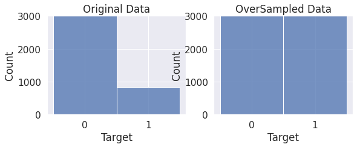

```python
#plotting
plt.figure(figsize=(14, 3))

plt.subplot(1, 3, 1)
ax=sns.histplot(y_train['Target'].apply(str));
plt.ylim([0, 3000]);
plt.title('Original Data');

plt.subplot(1, 3, 2)
ax=sns.histplot(y_train_over['Target'].apply(str));
plt.ylim([0, 3000]);
plt.title('OverSampled Data');
```

```python
models_over = []  # Empty list to store all the models

# Appending models into the list
models_over.append(("LR", LogisticRegression(random_state=1)))
models_over.append(("dtree", DecisionTreeClassifier(random_state=1)))
models_over.append(("Bagging", BaggingClassifier(random_state=1)))
models_over.append(("Random Forest", RandomForestClassifier(random_state=1)))
models_over.append(("GBM", GradientBoostingClassifier(random_state=1)))
models_over.append(("Adaboost", AdaBoostClassifier(random_state=1)))
models_over.append(("Xgboost", XGBClassifier(random_state=1, eval_metric="logloss")))

results_over = []  # Empty list to store all model's CV scores
names_over = []  # Empty list to store name of the models


# loop through all models to get the mean cross validated score
print("\n" "Cross-Validation performance on training dataset:" "\n")

for name, model in models_over:
    kfold = StratifiedKFold(
        n_splits=5, shuffle=True, random_state=1
    )  # Setting number of splits equal to 5
    cv_result = cross_val_score(
        estimator=model, X=X_train, y=y_train, scoring=scorer, cv=kfold
    )
    results1.append(cv_result)
    names.append(name)
    print("{}: {}".format(name, cv_result.mean()))

print("\n" "Validation Performance:" "\n")

for name, model in models:
    model.fit(X_train, y_train)
    scores = recall_score(y_val, model.predict(X_val))
    print("{}: {}".format(name, scores))
```

```
Cross-Validation performance on training dataset:

LR: 0.4927566553639709
dtree: 0.6982829521679532
Bagging: 0.7210807301060529
Random Forest: 0.7223144073299184
GBM: 0.7066589712141981
Adaboost: 0.6309140754635308
Xgboost: 0.7427314046605584

Validation Performance:

LR: 0.48201438848920863
dtree: 0.7050359712230215
Bagging: 0.7302158273381295
Random Forest: 0.7266187050359713
GBM: 0.7230215827338129
Adaboost: 0.6762589928057554
Xgboost: 0.762589928057554
```

```python
# Training Data performance
```

```python
# creating empty data frame With NaN values
df_metrics_train_over = pd.DataFrame(columns = ['Accuracy', 'Recall', 'Precision', 'F1'])

# adding rows to the empty data frame
for name, model in models_over:
    df_metrics_train_over.loc[name] = model_performance_classification_sklearn(model.fit(X_train_over, y_train_over), X_train_over, y_train_over).loc[0]

df_metrics_train_over
```

|  | Accuracy | Recall | Precision | F1 |
| --- | --- | --- | --- | --- |
| LR | 0.880 | 0.884 | 0.878 | 0.881 |
| dtree | 1.000 | 1.000 | 1.000 | 1.000 |
| Bagging | 0.999 | 0.998 | 1.000 | 0.999 |
| Random Forest | 1.000 | 1.000 | 1.000 | 1.000 |
| GBM | 0.954 | 0.931 | 0.976 | 0.953 |
| Adaboost | 0.914 | 0.903 | 0.923 | 0.913 |
| Xgboost | 0.952 | 0.926 | 0.976 | 0.950 |

```python
# Validation Data performance
```

```python
# creating empty data frame With NaN values
df_metrics_val_over = pd.DataFrame(columns = ['Accuracy', 'Recall', 'Precision', 'F1'])

# adding rows to the empty data frame
for name, model in models_over:
    df_metrics_val_over.loc[name] = model_performance_classification_sklearn(model.fit(X_train_over, y_train_over), X_val, y_val).loc[0]

df_metrics_val_over
```

|  | Accuracy | Recall | Precision | F1 |
| --- | --- | --- | --- | --- |
| LR | 0.868 | 0.849 | 0.277 | 0.417 |
| dtree | 0.949 | 0.777 | 0.531 | 0.631 |
| Bagging | 0.979 | 0.831 | 0.802 | 0.816 |
| Random Forest | 0.989 | 0.853 | 0.937 | 0.893 |
| GBM | 0.964 | 0.878 | 0.622 | 0.728 |
| Adaboost | 0.912 | 0.856 | 0.374 | 0.520 |
| Xgboost | 0.963 | 0.874 | 0.618 | 0.724 |

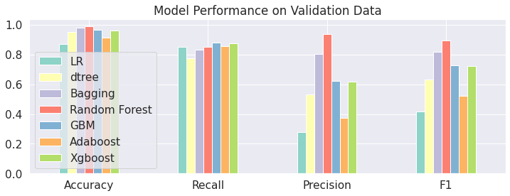

```python
#setting color
color=sns. set_palette("Set3");

#plotting
df_metrics_val_over.T.plot(kind="bar", figsize=(12, 4));
plt.legend(df_metrics_val_over.T.columns.tolist(), loc='lower left');
plt.xticks(rotation=0);
plt.title('Model Performance on Validation Data');
```

### Model Building with Undersampled data

```python
# Random undersampler for under sampling the data
rus = RandomUnderSampler(random_state=1, sampling_strategy=1)
X_train_un, y_train_un = rus.fit_resample(X_train, y_train)

print("\nNumber (percentage) of {} in the undersampled training set:".format(target))
print("failure:      {0} ({1:2.2f}%)".format(y_train_un[target].value_counts()[1], y_train_un[target].value_counts(normalize=True)[1] * 100 ))
print("no failure:   {0} ({1:2.2f}%)".format(y_train_un[target].value_counts()[0], y_train_un[target].value_counts(normalize=True)[0] * 100 ))
```

```
Number (percentage) of Target in the undersampled training set:
failure:      832 (50.00%)
no failure:   832 (50.00%)
```

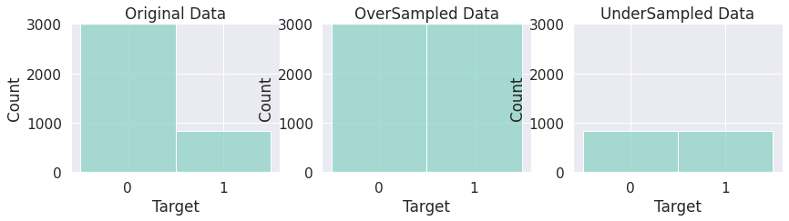

```python
#plotting
plt.figure(figsize=(14, 3))

plt.subplot(1, 3, 1)
ax=sns.histplot(y_train['Target'].apply(str));
plt.ylim([0, 3000]);
plt.title('Original Data');

plt.subplot(1, 3, 2)
ax=sns.histplot(y_train_over['Target'].apply(str));
plt.ylim([0, 3000]);
plt.title('OverSampled Data');

plt.subplot(1, 3, 3)
ax=sns.histplot(y_train_un['Target'].apply(str));
plt.ylim([0, 3000]);
plt.title('UnderSampled Data');
```

```python
models_un = []  # Empty list to store all the models

# Appending models into the list
models_un.append(("LR", LogisticRegression(random_state=1)))
models_un.append(("dtree", DecisionTreeClassifier(random_state=1)))
models_un.append(("Bagging", BaggingClassifier(random_state=1)))
models_un.append(("Random Forest", RandomForestClassifier(random_state=1)))
models_un.append(("GBM", GradientBoostingClassifier(random_state=1)))
models_un.append(("Adaboost", AdaBoostClassifier(random_state=1)))
models_un.append(("Xgboost", XGBClassifier(random_state=1, eval_metric="logloss")))

results_un = []  # Empty list to store all model's CV scores
names_un = []  # Empty list to store name of the models


# loop through all models to get the mean cross validated score
print("\n" "Cross-Validation performance on training dataset:" "\n")

for name, model in models_un:
    kfold = StratifiedKFold(
        n_splits=5, shuffle=True, random_state=1
    )  # Setting number of splits equal to 5
    cv_result = cross_val_score(
        estimator=model, X=X_train, y=y_train, scoring=scorer, cv=kfold
    )
    results1.append(cv_result)
    names.append(name)
    print("{}: {}".format(name, cv_result.mean()))

print("\n" "Validation Performance:" "\n")

for name, model in models:
    model.fit(X_train, y_train)
    scores = recall_score(y_val, model.predict(X_val))
    print("{}: {}".format(name, scores))
```

```
Cross-Validation performance on training dataset:

LR: 0.4927566553639709
dtree: 0.6982829521679532
Bagging: 0.7210807301060529
Random Forest: 0.7223144073299184
GBM: 0.7066589712141981
Adaboost: 0.6309140754635308
Xgboost: 0.7427314046605584

Validation Performance:

LR: 0.48201438848920863
dtree: 0.7050359712230215
Bagging: 0.7302158273381295
Random Forest: 0.7266187050359713
GBM: 0.7230215827338129
Adaboost: 0.6762589928057554
Xgboost: 0.762589928057554
```

```python
# Training Data performance
```

```python
# creating empty data frame With NaN values
df_metrics_train_un = pd.DataFrame(columns = ['Accuracy', 'Recall', 'Precision', 'F1'])

# adding rows to the empty data frame
for name, model in models_un:
    df_metrics_train_un.loc[name] = model_performance_classification_sklearn(model.fit(X_train_un, y_train_un), X_train_un, y_train_un).loc[0]

df_metrics_train_un
```

|  | Accuracy | Recall | Precision | F1 |
| --- | --- | --- | --- | --- |
| LR | 0.873 | 0.875 | 0.872 | 0.873 |
| dtree | 1.000 | 1.000 | 1.000 | 1.000 |
| Bagging | 0.990 | 0.983 | 0.998 | 0.990 |
| Random Forest | 1.000 | 1.000 | 1.000 | 1.000 |
| GBM | 0.965 | 0.940 | 0.989 | 0.964 |
| Adaboost | 0.922 | 0.905 | 0.938 | 0.921 |
| Xgboost | 0.960 | 0.929 | 0.991 | 0.959 |

```python
# Validation Data performance
```

```python
# creating empty data frame With NaN values
df_metrics_val_un = pd.DataFrame(columns = ['Accuracy', 'Recall', 'Precision', 'F1'])

# adding rows to the empty data frame
for name, model in models_un:
    df_metrics_val_un.loc[name] = model_performance_classification_sklearn(model.fit(X_train_un, y_train_un), X_val, y_val).loc[0]

df_metrics_val_un
```

|  | Accuracy | Recall | Precision | F1 |
| --- | --- | --- | --- | --- |
| LR | 0.857 | 0.853 | 0.260 | 0.399 |
| dtree | 0.831 | 0.842 | 0.226 | 0.356 |
| Bagging | 0.928 | 0.871 | 0.428 | 0.574 |
| Random Forest | 0.947 | 0.892 | 0.515 | 0.653 |
| GBM | 0.930 | 0.888 | 0.438 | 0.587 |
| Adaboost | 0.877 | 0.849 | 0.292 | 0.435 |
| Xgboost | 0.940 | 0.888 | 0.481 | 0.624 |

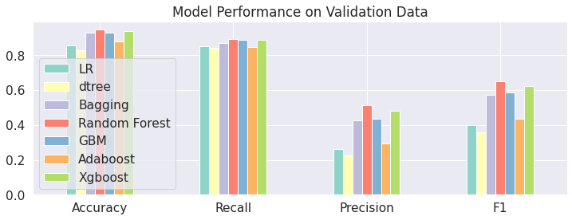

```python
#setting color
color=sns. set_palette("Set3");

#plotting
df_metrics_val_un.T.plot(kind="bar", figsize=(12, 4));
plt.legend(df_metrics_val_un.T.columns.tolist(), loc='lower left');
plt.xticks(rotation=0);
plt.title('Model Performance on Validation Data');
```

## HyperparameterTuning

```python
models_comp_df_train = pd.concat(
    [ df_metrics_train.T, df_metrics_train_over.T,  df_metrics_train_un.T]
    , axis=1)

print("\nperformance summary of all models on training set:")
models_comp_df_train.T
```

```
performance summary of all models on training set:
```

|  | Accuracy | Recall | Precision | F1 |
| --- | --- | --- | --- | --- |
| LR | 0.967 | 0.495 | 0.843 | 0.624 |
| dtree | 1.000 | 1.000 | 1.000 | 1.000 |
| Bagging | 0.997 | 0.957 | 0.997 | 0.977 |
| Random Forest | 1.000 | 1.000 | 1.000 | 1.000 |
| GBM | 0.989 | 0.819 | 0.986 | 0.894 |
| Adaboost | 0.978 | 0.659 | 0.923 | 0.769 |
| Xgboost | 0.989 | 0.814 | 0.990 | 0.893 |
| LR | 0.880 | 0.884 | 0.878 | 0.881 |
| dtree | 1.000 | 1.000 | 1.000 | 1.000 |
| Bagging | 0.999 | 0.998 | 1.000 | 0.999 |
| Random Forest | 1.000 | 1.000 | 1.000 | 1.000 |
| GBM | 0.954 | 0.931 | 0.976 | 0.953 |
| Adaboost | 0.914 | 0.903 | 0.923 | 0.913 |
| Xgboost | 0.952 | 0.926 | 0.976 | 0.950 |
| LR | 0.873 | 0.875 | 0.872 | 0.873 |
| dtree | 1.000 | 1.000 | 1.000 | 1.000 |
| Bagging | 0.990 | 0.983 | 0.998 | 0.990 |
| Random Forest | 1.000 | 1.000 | 1.000 | 1.000 |
| GBM | 0.965 | 0.940 | 0.989 | 0.964 |
| Adaboost | 0.922 | 0.905 | 0.938 | 0.921 |
| Xgboost | 0.960 | 0.929 | 0.991 | 0.959 |

```python
models_comp_df_val = pd.concat(
    [ df_metrics_val.T, df_metrics_val_over.T,  df_metrics_val_un.T]
    , axis=1)

print("\nperformance summary of all models on validation set:")
models_comp_df_val.T
```

```
performance summary of all models on validation set:
```

|  | Accuracy | Recall | Precision | F1 |
| --- | --- | --- | --- | --- |
| LR | 0.966 | 0.482 | 0.843 | 0.613 |
| dtree | 0.966 | 0.705 | 0.688 | 0.696 |
| Bagging | 0.983 | 0.730 | 0.949 | 0.825 |
| Random Forest | 0.984 | 0.727 | 0.985 | 0.836 |
| GBM | 0.981 | 0.723 | 0.914 | 0.807 |
| Adaboost | 0.976 | 0.676 | 0.866 | 0.760 |
| Xgboost | 0.985 | 0.763 | 0.959 | 0.850 |
| LR | 0.868 | 0.849 | 0.277 | 0.417 |
| dtree | 0.949 | 0.777 | 0.531 | 0.631 |
| Bagging | 0.979 | 0.831 | 0.802 | 0.816 |
| Random Forest | 0.989 | 0.853 | 0.937 | 0.893 |
| GBM | 0.964 | 0.878 | 0.622 | 0.728 |
| Adaboost | 0.912 | 0.856 | 0.374 | 0.520 |
| Xgboost | 0.963 | 0.874 | 0.618 | 0.724 |
| LR | 0.857 | 0.853 | 0.260 | 0.399 |
| dtree | 0.831 | 0.842 | 0.226 | 0.356 |
| Bagging | 0.928 | 0.871 | 0.428 | 0.574 |
| Random Forest | 0.947 | 0.892 | 0.515 | 0.653 |
| GBM | 0.930 | 0.888 | 0.438 | 0.587 |
| Adaboost | 0.877 | 0.849 | 0.292 | 0.435 |
| Xgboost | 0.940 | 0.888 | 0.481 | 0.624 |

```python
# Each set of models is stacked (original, oversampled, undersampled) from top to bottom.
```

```python
# Given we want to maximize recall in order to minimize false negatives.
```

```python
# I have selected: Random Forest(under), GBM(under), GBM(over).
```

```python
# I selected the GBM over even though other models edge it out on recall because of the high accuracy and need
# to diversify model selection. I did not want to conisder only undersampled models for hyperparameter tuning.
```

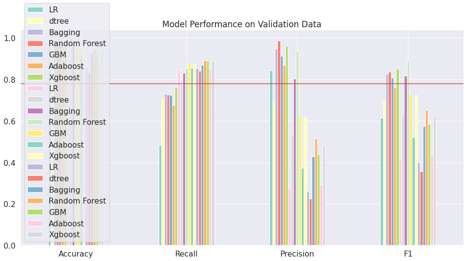

```python
#setting color
color=sns.set_palette("Set3");

#plotting
models_comp_df_val.plot(kind="bar", figsize=(16, 8));
plt.legend(models_comp_df_val.columns.tolist(), loc='lower left');
plt.xticks(rotation=0);
# adding a horizontal line
plt.axhline(y=0.78, color='r', linestyle='-', label="score threshold")

plt.title('Model Performance on Validation Data');
```

### Sample Parameter Grids

**Hyperparameter tuning can take a long time to run, so to avoid that time complexity - you can use the following grids, wherever required.**

- For Gradient Boosting:

param_grid = { "n_estimators": np.arange(100,150,25), "learning_rate": [0.2, 0.05, 1], "subsample":[0.5,0.7], "max_features":[0.5,0.7] }

- For Adaboost:

param_grid = { "n_estimators": [100, 150, 200], "learning_rate": [0.2, 0.05], "base_estimator": [DecisionTreeClassifier(max_depth=1, random_state=1), DecisionTreeClassifier(max_depth=2, random_state=1), DecisionTreeClassifier(max_depth=3, random_state=1), ] }

- For Bagging Classifier:

param_grid = { 'max_samples': [0.8,0.9,1], 'max_features': [0.7,0.8,0.9], 'n_estimators' : [30,50,70], }

- For Random Forest:

param_grid = { "n_estimators": [200,250,300], "min_samples_leaf": np.arange(1, 4), "max_features": [np.arange(0.3, 0.6, 0.1),'sqrt'], "max_samples": np.arange(0.4, 0.7, 0.1) }

- For Decision Trees:

param_grid = { 'max_depth': np.arange(2,6), 'min_samples_leaf': [1, 4, 7], 'max_leaf_nodes' : [10, 15], 'min_impurity_decrease': [0.0001,0.001] }

- For Logistic Regression:

param_grid = {'C': np.arange(0.1,1.1,0.1)}

- For XGBoost:

param_grid={ 'n_estimators': [150, 200, 250], 'scale_pos_weight': [5,10], 'learning_rate': [0.1,0.2], 'gamma': [0,3,5], 'subsample': [0.8,0.9] }

```python
# Random Forest_over, Xgboost_over, and dtree_over classifiers
Random_Forest_under = RandomForestClassifier(random_state=1);
GBM_under= GradientBoostingClassifier(random_state=1);
GBM_over= XGBClassifier(random_state=1);

# fitting models on oversampled training set
Random_Forest_under.fit(X_train_un, y_train_un);
GBM_under.fit(X_train_un, y_train_un);
GBM_over.fit(X_train_over, y_train_over);
```

```python
%%time

# defining model
model = Random_Forest_under

# Parameter grid to pass in RandomizedSearchCV

param_grid = { "n_estimators": [200,250,300], "min_samples_leaf": np.arange(1, 4), "max_features": [np.arange(0.3, 0.6, 0.1),'sqrt'], "max_samples": np.arange(0.4, 0.7, 0.1) }


# Type of scoring used to compare parameter combinations
scoring = scorer

#Calling RandomizedSearchCV
randomized_cv = RandomizedSearchCV(estimator=model, param_distributions=param_grid, n_jobs = -1, n_iter=20, scoring=scoring, cv=5, random_state=1)

#Fitting parameters in RandomizedSearchCV
randomized_cv.fit(X_train,y_train)

print("Best parameters are {} with CV score={}:" .format(randomized_cv.best_params_,randomized_cv.best_score_))
```

```
Best parameters are {'n_estimators': 250, 'min_samples_leaf': 1, 'max_samples': 0.6, 'max_features': 'sqrt'} with CV score=0.6996248466921577:
CPU times: user 29.6 s, sys: 878 ms, total: 30.5 s
Wall time: 13min 30s
```

```python
# Set the model to the best combination of parameters
#Random_Forest_over_tuned = randomized_cv.best_estimator_
Random_Forest_under_tuned = RandomForestClassifier(
    random_state=1,
    n_estimators=250,
    min_samples_leaf= 1,
    max_samples= 0.6,
    max_features= 'sqrt'
)

# Fit the model on training data
Random_Forest_under_tuned.fit(X_train, y_train);
```

```python
model= Random_Forest_under_tuned

# creating empty data frame With NaN values
df_metrics_tuned_rf = pd.DataFrame(columns = ['Accuracy', 'Recall', 'Precision', 'F1'])

# adding rows to the empty data frame
df_metrics_tuned_rf.loc['train'] = model_performance_classification_sklearn(model.fit(X_train, y_train), X_train, y_train).loc[0]
df_metrics_tuned_rf.loc['val'] = model_performance_classification_sklearn(model.fit(X_train, y_train), X_val, y_val).loc[0]
print("\nperformance of tuned random forest on training and validation set:")
df_metrics_tuned_rf
```

```
performance of tuned random forest on training and validation set:
```

|  | Accuracy | Recall | Precision | F1 |
| --- | --- | --- | --- | --- |
| train | 0.995 | 0.910 | 1.000 | 0.953 |
| val | 0.984 | 0.716 | 0.985 | 0.829 |

```python
%%time

# defining model
model = GBM_under

# Parameter grid to pass in RandomizedSearchCV

param_grid = { "n_estimators": np.arange(100,150,25), "learning_rate": [0.2, 0.05, 1], "subsample":[0.5,0.7], "max_features":[0.5,0.7] }

# Type of scoring used to compare parameter combinations
scoring = scorer

#Calling RandomizedSearchCV
randomized_cv = RandomizedSearchCV(estimator=model, param_distributions=param_grid, n_jobs = -1, n_iter=20, scoring=scoring, cv=5, random_state=1)

#Fitting parameters in RandomizedSearchCV
randomized_cv.fit(X_train,y_train)

print("Best parameters are {} with CV score={}:" .format(randomized_cv.best_params_,randomized_cv.best_score_))
```

```
Best parameters are {'subsample': 0.7, 'n_estimators': 125, 'max_features': 0.5, 'learning_rate': 0.2} with CV score=0.7536974244282518:
CPU times: user 14.2 s, sys: 449 ms, total: 14.6 s
Wall time: 9min 48s
```

```python
# Set the model to the best combination of parameters
#Random_Forest_over_tuned = randomized_cv.best_estimator_
GBM_under_tuned = GradientBoostingClassifier(
    subsample = 0.7,
    random_state=1,
    n_estimators=125,
    max_features= 0.5,
    learning_rate = 0.2
)

# Fit the model on training data
GBM_under_tuned.fit(X_train, y_train);
```

```python
model= GBM_under_tuned

# creating empty data frame With NaN values
df_metrics_tuned_gbm_under = pd.DataFrame(columns = ['Accuracy', 'Recall', 'Precision', 'F1'])

# adding rows to the empty data frame
df_metrics_tuned_gbm_under.loc['train'] = model_performance_classification_sklearn(model.fit(X_train, y_train), X_train, y_train).loc[0]
df_metrics_tuned_gbm_under.loc['val'] = model_performance_classification_sklearn(model.fit(X_train, y_train), X_val, y_val).loc[0]
print("\nperformance of tuned random forest on training and validation set:")
df_metrics_tuned_gbm_under
```

[output not shown]

|  | Accuracy | Recall | Precision | F1 |
| --- | --- | --- | --- | --- |
| train | 0.995 | 0.913 | 0.992 | 0.951 |
| val | 0.982 | 0.781 | 0.882 | 0.828 |

```python
%%time

# defining model
model = GBM_over

# Parameter grid to pass in RandomizedSearchCV

param_grid = { "n_estimators": np.arange(100,150,25), "learning_rate": [0.2, 0.05, 1], "subsample":[0.5,0.7], "max_features":[0.5,0.7] }

# Type of scoring used to compare parameter combinations
scoring = scorer

#Calling RandomizedSearchCV
randomized_cv = RandomizedSearchCV(estimator=model, param_distributions=param_grid, n_jobs = -1, n_iter=20, scoring=scoring, cv=5, random_state=1)

#Fitting parameters in RandomizedSearchCV
randomized_cv.fit(X_train,y_train)

print("Best parameters are {} with CV score={}:" .format(randomized_cv.best_params_,randomized_cv.best_score_))
```

```
Best parameters are {'subsample': 0.7, 'n_estimators': 125, 'max_features': 0.5, 'learning_rate': 1} with CV score=0.7873602193203955:
CPU times: user 6.8 s, sys: 301 ms, total: 7.1 s
Wall time: 4min 33s
```

```python
# Set the model to the best combination of parameters
#Random_Forest_over_tuned = randomized_cv.best_estimator_
GBM_over_tuned = GradientBoostingClassifier(
    subsample = 0.7,
    random_state=1,
    n_estimators=125,
    max_features= 0.5,
    learning_rate = 1
)

# Fit the model on training data
GBM_under_tuned.fit(X_train, y_train);
```

```python
model= GBM_over_tuned

# creating empty data frame With NaN values
df_metrics_tuned_gbm_over = pd.DataFrame(columns = ['Accuracy', 'Recall', 'Precision', 'F1'])

# adding rows to the empty data frame
df_metrics_tuned_gbm_over.loc['train'] = model_performance_classification_sklearn(model.fit(X_train, y_train), X_train, y_train).loc[0]
df_metrics_tuned_gbm_over.loc['val'] = model_performance_classification_sklearn(model.fit(X_train, y_train), X_val, y_val).loc[0]
print("\nperformance of tuned random forest on training and validation set:")
df_metrics_tuned_gbm_over
```

[output not shown]

|  | Accuracy | Recall | Precision | F1 |
| --- | --- | --- | --- | --- |
| train | 0.963 | 0.600 | 0.697 | 0.645 |
| val | 0.953 | 0.507 | 0.588 | 0.544 |

## Model performance comparison and choosing the final model

```python
# creating empty data frame With NaN values
df_all_train_tuned = pd.DataFrame(columns = ['Accuracy', 'Recall', 'Precision', 'F1'])

# adding rows to the empty data frame
df_all_train_tuned.loc['Random_Forest_over_tuned'] = df_metrics_tuned_rf.loc['train']
df_all_train_tuned.loc['Gradient Boost Under'] = df_metrics_tuned_gbm_under.loc['train']
df_all_train_tuned.loc['Gradient Boost Over'] = df_metrics_tuned_gbm_over.loc['train']
print("\nperformance of tuned models on training set:")
df_all_train_tuned
```

```
performance of tuned models on training set:
```

[output not shown]

```python
# creating empty data frame With NaN values
df_all_val_tuned = pd.DataFrame(columns = ['Accuracy', 'Recall', 'Precision', 'F1'])

# adding rows to the empty data frame
df_all_val_tuned.loc['Random_Forest_over_tuned'] = df_metrics_tuned_rf.loc['val']
df_all_val_tuned.loc['Xgboost_over_tuned'] = df_metrics_tuned_gbm_under.loc['val']
df_all_val_tuned.loc['dtree_over_tuned'] = df_metrics_tuned_gbm_over.loc['val']
print("\nperformance of tuned models on validation set:")
df_all_val_tuned
```

```
performance of tuned models on validation set:
```

[output not shown]

## Pipelines to build the final model

```python
# Creating new pipeline with best parameters
model_pipeline = Pipeline(
    steps=[
        ("imputer", KNNImputer(n_neighbors=5) ),
        ("XGBoost Over-Tuned", XGBClassifier(
                random_state=1,
                n_estimators=125,
                max_features = 0.5,
                learning_rate = 1,
                subsample = 0.7
            ),
        ),
    ]
)
# Fit the model on training data
model_pipeline.fit(X_train_over, y_train_over)
```

```
Pipeline(steps=[('imputer', KNNImputer()),
                ('XGBoost Over-Tuned',
                 XGBClassifier(learning_rate=1, max_features=0.5,
                               n_estimators=125, random_state=1,
                               subsample=0.7))])
```

```python
y_predict= model_pipeline.predict(X_test);

# predictions on the test set
df_pred_test = pd.DataFrame({"Actual": y_test['Target'], "Predicted": y_predict})
df_pred_test.head(10)
```

|  | Actual | Predicted |
| --- | --- | --- |
| 0 | 0 | 0 |
| 1 | 0 | 0 |
| 2 | 0 | 0 |
| 3 | 0 | 0 |
| 4 | 0 | 0 |
| 5 | 0 | 0 |
| 6 | 0 | 0 |
| 7 | 0 | 0 |
| 8 | 0 | 0 |
| 9 | 0 | 0 |

# Business Insights and Conclusions